# Mall Customers Capstone

Samantha Jones

2024-10-07

Introduction: An owner of a supermarket mall with active customer memberships wants to analyze some basic customers information from their memberships such as:Customer Id,Gender,Age,Annual Income,Spending Score. Spending Score is assigned to customers based on the owner perimeters of customer behavior and purchasing data.

Problem: Owner wants to understand who their Target Audience is? For their marketing team to increase their promotional strategies.

```r
library(readr)
Mall_Customers <- read_csv("Mall_Customers.csv")
summary(Mall_Customers)
```

```
##    CustomerID        Gender               Age        Annual Income (k$)
##  Min.   :  1.00   Length:200         Min.   :18.00   Min.   : 15.00
##  1st Qu.: 50.75   Class :character   1st Qu.:28.75   1st Qu.: 41.50
##  Median :100.50   Mode  :character   Median :36.00   Median : 61.50
##  Mean   :100.50                      Mean   :38.85   Mean   : 60.56
##  3rd Qu.:150.25                      3rd Qu.:49.00   3rd Qu.: 78.00
##  Max.   :200.00                      Max.   :70.00   Max.   :137.00
##  Spending Score (1-100)
##  Min.   : 1.00
##  1st Qu.:34.75
##  Median :50.00
##  Mean   :50.20
##  3rd Qu.:73.00
##  Max.   :99.00
```

```r
library(tidyverse)
```

```r
library(ggplot2)
library(conflicted)
library(dbplyr)
```

Check for missing values:

```r
sum(is.na(Mall_Customers))
```

```
## [1] 0
```

Check for duplicates:

```r
duplicated_rows <- duplicated(Mall_Customers)
sum(duplicated_rows)
```

```
## [1] 0
```

Rename columns for clarity:

```r
names(Mall_Customers) <- c("CustomerID", "Gender", "Age", "Annual_Income", "Spending_Score")
```

Convert the annual income from double digits $15 and currency K$ into thousands as this will make for a more accurate annual income column in US dollars:

```r
Mall_Customers$Annual_Income <- (Mall_Customers$Annual_Income * 1000)
summary(Mall_Customers)
```

```
##    CustomerID        Gender               Age        Annual_Income
##  Min.   :  1.00   Length:200         Min.   :18.00   Min.   : 15000
##  1st Qu.: 50.75   Class :character   1st Qu.:28.75   1st Qu.: 41500
##  Median :100.50   Mode  :character   Median :36.00   Median : 61500
##  Mean   :100.50                      Mean   :38.85   Mean   : 60560
##  3rd Qu.:150.25                      3rd Qu.:49.00   3rd Qu.: 78000
##  Max.   :200.00                      Max.   :70.00   Max.   :137000
##  Spending_Score
##  Min.   : 1.00
##  1st Qu.:34.75
##  Median :50.00
##  Mean   :50.20
##  3rd Qu.:73.00
##  Max.   :99.00
```

Data type conversion:

```r
Mall_Customers$Annual_Income <- as.numeric(Mall_Customers$Annual_Income)
Mall_Customers$Spending_Score <- as.numeric(Mall_Customers$Spending_Score)
```

Segmentation by Gender:

```r
aggregate(cbind(Annual_Income, Spending_Score)~ Gender, data = Mall_Customers, FUN = mean)
```

```
##   Gender Annual_Income Spending_Score
## 1 Female      59250.00       51.52679
## 2   Male      62227.27       48.51136
```

As you can see even though Men make almost about 3000 dollars more than Women spend about 3% according to Spending Score.

Customer Age Grouping: Create age groups to study patterns across age brackets.

```r
Mall_Customers$Age_Group <- cut(Mall_Customers$Age,
                                breaks = c(0, 20, 40, 60, 80), labels = c("0-20", "21-40", "41-60", "61-80"))
aggregate(Spending_Score ~ Age_Group, data = Mall_Customers, FUN = mean)
```

```
##   Age_Group Spending_Score
## 1      0-20       44.64706
## 2     21-40       61.66667
## 3     41-60       33.68852
## 4     61-80       44.17647
```

As you can see from the data table the age groups that spend the most range from ages 21-40.

Annual Income Analysis: Divide income into categories to study correlations with spending.

```r
Mall_Customers$Income_Group <- cut(Mall_Customers$Annual_Income, breaks = 4, labels = c("Low", "Mid", "High", "Very High"))
aggregate(Spending_Score ~ Income_Group, data = Mall_Customers, FUN = mean)
```

```
##   Income_Group Spending_Score
## 1          Low       49.68966
## 2          Mid       50.33721
## 3         High       50.66667
## 4    Very High       49.62500
```

[output not shown]

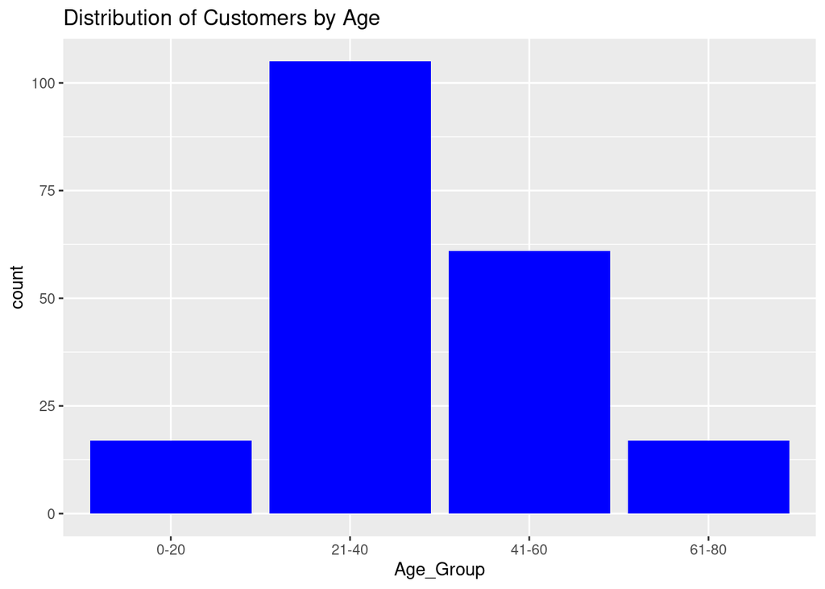

```r
ggplot(Mall_Customers, aes(x = Age_Group)) + geom_bar(fill = "blue") + ggtitle("Distribution of Customers by Age")
```

Analysis: What age group spends the most?

Age group that shops the most is ranging between 21-40

Spending Score by Gender:

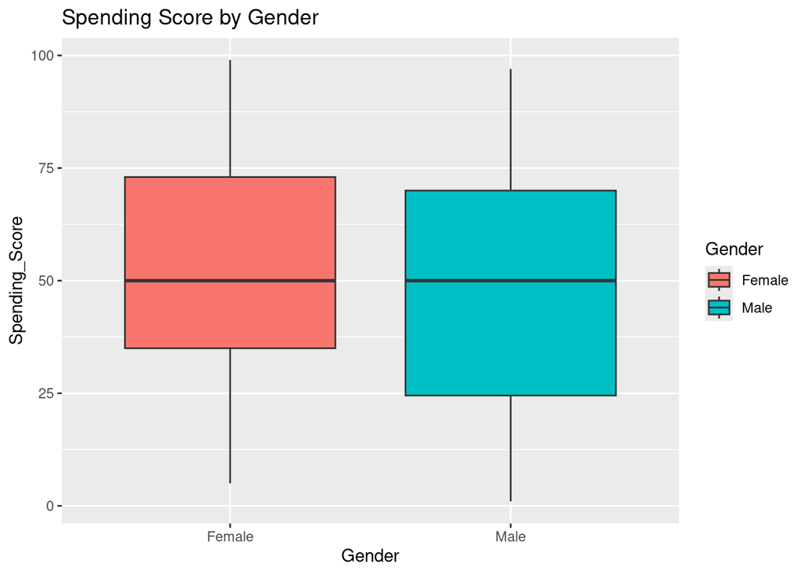

```r
ggplot(Mall_Customers, aes(x = Gender, y = Spending_Score, fill = Gender)) + geom_boxplot() + ggtitle("Spending Score by Gender")
```

Analysis: Which gender has a higher Spending Score?

Data shows that women have a higher Spending Score then men

Annual Income vs. Spending Score:

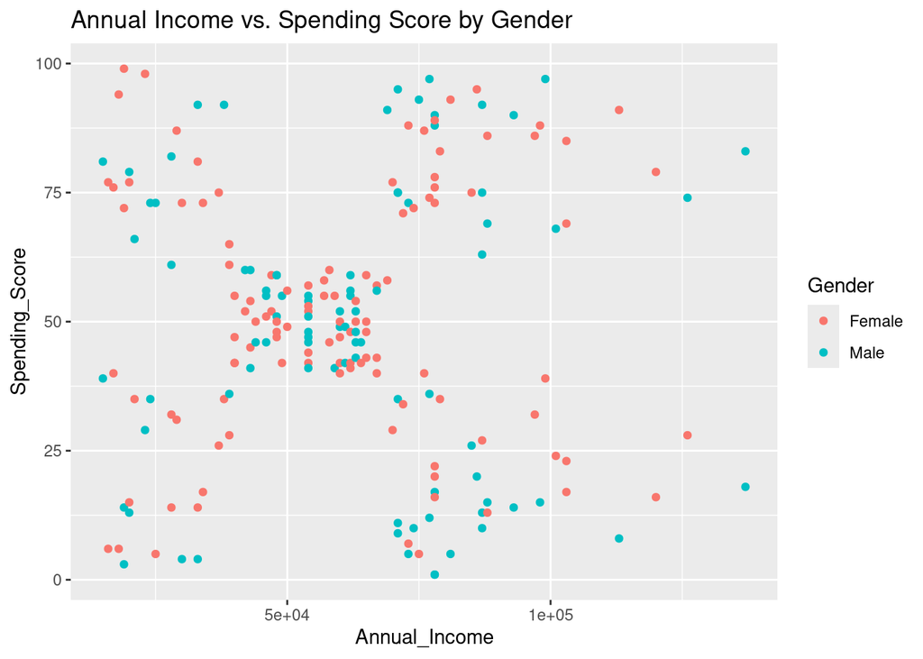

```r
ggplot(Mall_Customers, aes(x = Annual_Income, y = Spending_Score, color = Gender)) + geom_point() + ggtitle("Annual Income vs. Spending Score by Gender")
```

Analyis: Is there a positive correlation between income and spending habits? Does Gender influence this?

The bulk of both genders that make between 40000-70000 have just about the same spending habits. I don’t believe gender is a major influnce on this because genders that make above 100k spend either less or more, those making below 50k have a low or high spending score as well.

Income Group vs. Spending Score:

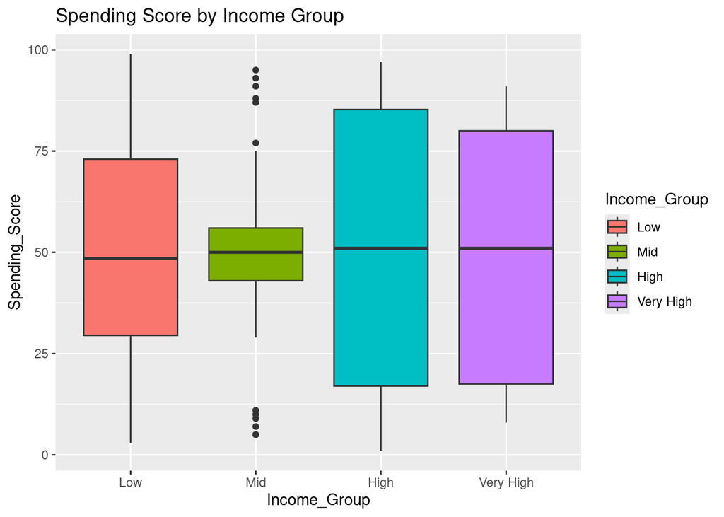

```r
ggplot(Mall_Customers, aes(x = Income_Group, y = Spending_Score, fill = Income_Group)) + geom_boxplot() + ggtitle("Spending Score by Income Group")
```

Analysis: Does a higher income group translate into higher spending?

Low Range Income:15000-44000

Mid Range Income:46000-76000

High Range Income:77000-103000

Very High Range Income: 113000-137000

Mid range income spending score falls within the 50 range, shoppers either below or above the average range

Very high range income spending score is within the 15-75 range is consistent as well

CONCLUSION:

Both male and female spending habits were just about the same, women just slight spend a little more than men.

To further dive into this dataset maybe a catagory for items customers shop for i.e.(Electronic,Groceries,Clothing,Travel) would have helped to see where customers spend the most frequent.I believe if that data was present the marketing team could run sells/ads more geared towards those items.

However since the target age audience is 21-40, advertisement on social media would be very benefical to the owner.